# Detection de Fraude

Anicet DJISSOU

05/04/2021

Dans tous les pays, le système financier est l’un des indicateurs les plus importants de son developpement économique et social.Il est principal pour une croissance économique. La banque est devenue l’un des acteurs essentiels au bon fonctionnement de cette économie. Son activité est caractérisée par sa diversité qui consiste en la collecte des dépôts, la distribution des crédits, l’animation des marchés financiers et la gestion des moyens de paiment.C’est ainsi que les banques sont de plus en plus ménacées par une multitude de risques qui peuvent nuire à leur activité. Parmi les différents type de risque,nous avons la fraude. De nous jours les techniques de fraude evoluent sans cesse et la fraudecoûte cher aux entreprise. la detection de fraude par des méthodes de machine learning est l’un des outils d’aide à la décision utilisés par la banque pour lui permettre de détecter la fraude. Dans ce projet nous allons construire des algorithmes capable de prédire si la transaction éffectué par le client est une fraude ou pas.Il s’agit donc d’un probleme de classification car nous allons prédire une variable binaire.

# Importation des librairies et des données

```r
library(caret)
library(tidyverse)
library(ROSE)
library(randomForest)
```

```r
library(ggplot2)
library(caret)
```

En ce qui concerne les données, il s’agit des informations collectées sur d’anciens clients d’une banque qui sont utilisés pour prédire le comportement des nouveaux clients.Ces données proviennent de kaggle qui est la plateforme la plus célèbre en matière de compétition en Data Science. Nous allons utiliserces données historiques afin de construire un modèle qui va prédire le statut des nouveaux transactions.

```r
url="https://raw.githubusercontent.com/anicetdjissou/Modele_1/master/base/fraud.txt"
df=read.csv(url)

head(df)
```

```
##   step     type   amount    nameOrig oldbalanceOrg newbalanceOrig    nameDest
## 1    1  PAYMENT  9839.64 C1231006815        170136      160296.36 M1979787155
## 2    1  PAYMENT  1864.28 C1666544295         21249       19384.72 M2044282225
## 3    1 TRANSFER   181.00 C1305486145           181           0.00  C553264065
## 4    1 CASH_OUT   181.00  C840083671           181           0.00   C38997010
## 5    1  PAYMENT 11668.14 C2048537720         41554       29885.86 M1230701703
## 6    1  PAYMENT  7817.71   C90045638         53860       46042.29  M573487274
##   oldbalanceDest newbalanceDest isFraud isFlaggedFraud
## 1              0              0       0              0
## 2              0              0       0              0
## 3              0              0       1              0
## 4          21182              0       1              0
## 5              0              0       0              0
## 6              0              0       0              0
```

```r
dim(df)
```

```
## [1] 1048575      11
```

```r
str(df)
```

```
## 'data.frame':    1048575 obs. of  11 variables:
##  $ step          : int  1 1 1 1 1 1 1 1 1 1 ...
##  $ type          : chr  "PAYMENT" "PAYMENT" "TRANSFER" "CASH_OUT" ...
##  $ amount        : num  9840 1864 181 181 11668 ...
##  $ nameOrig      : chr  "C1231006815" "C1666544295" "C1305486145" "C840083671" ...
##  $ oldbalanceOrg : num  170136 21249 181 181 41554 ...
##  $ newbalanceOrig: num  160296 19385 0 0 29886 ...
##  $ nameDest      : chr  "M1979787155" "M2044282225" "C553264065" "C38997010" ...
##  $ oldbalanceDest: num  0 0 0 21182 0 ...
##  $ newbalanceDest: num  0 0 0 0 0 ...
##  $ isFraud       : int  0 0 1 1 0 0 0 0 0 0 ...
##  $ isFlaggedFraud: int  0 0 0 0 0 0 0 0 0 0 ...
```

```r
summary(df)
```

```
##       step           type               amount           nameOrig
##  Min.   : 1.00   Length:1048575     Min.   :       0   Length:1048575
##  1st Qu.:15.00   Class :character   1st Qu.:   12149   Class :character
##  Median :20.00   Mode  :character   Median :   76343   Mode  :character
##  Mean   :26.97                      Mean   :  158667
##  3rd Qu.:39.00                      3rd Qu.:  213762
##  Max.   :95.00                      Max.   :10000000
##  oldbalanceOrg      newbalanceOrig       nameDest         oldbalanceDest
##  Min.   :       0   Min.   :       0   Length:1048575     Min.   :       0
##  1st Qu.:       0   1st Qu.:       0   Class :character   1st Qu.:       0
##  Median :   16002   Median :       0   Mode  :character   Median :  126377
##  Mean   :  874006   Mean   :  893805                      Mean   :  978160
##  3rd Qu.:  136642   3rd Qu.:  174600                      3rd Qu.:  915923
##  Max.   :38939424   Max.   :38946233                      Max.   :42054660
##  newbalanceDest        isFraud         isFlaggedFraud
##  Min.   :       0   Min.   :0.000000   Min.   :0
##  1st Qu.:       0   1st Qu.:0.000000   1st Qu.:0
##  Median :  218260   Median :0.000000   Median :0
##  Mean   : 1114193   Mean   :0.001089   Mean   :0
##  3rd Qu.: 1149808   3rd Qu.:0.000000   3rd Qu.:0
##  Max.   :42169156   Max.   :1.000000   Max.   :0
```

Nous remarquons que les moyennes et les écart-types sont différents d’une variable à une autre. Les données ne sont pas à la même échelle.Il faudra donc normaliser les données avant de les modéliser. En effet certains algrithmes de machine learning nécessitent une normalisation des données pour avoir un meilleur résultat.

# Définition de nos variables

step : unité de temps: step 1 correspond à 1h pour un simulation de 30jours).

type : CASH-IN, CASH-OUT, DEBIT, PAYMENT et TRANSFER.

amount : le montant de la transaction en devise locale.

nameOrig : le nom du client qui a commencé la transaction.

oldbalanceOrg : le solde initial avant la transaction.

newbalanceOrig : le nouveau solde après la transaction.

nameDest : le nom du destinataire de la transaction.

oldbalanceDest :le solde initial du destinataire avant la transaction.

newbalanceDest : le nouveau solde du destinaire après la transaction.

isFraud : c’est la variable cible. elle indique que si la transaction est une faude (1) ou pas (0)

isFlaggedFraud : vise à contrôler les tranferts massifs. Un transaction de plus de 200000 en une seule transaction est fraude flagrante.

```r
df$isFraud=as.factor(df$isFraud)
df$isFlaggedFraud=as.factor(df$isFlaggedFraud)
```

La fréquence de la variable cible (isFraud)

```r
print(prop.table(table(df$isFraud)))
```

```
##
##           0           1
## 0.998910903 0.001089097
```

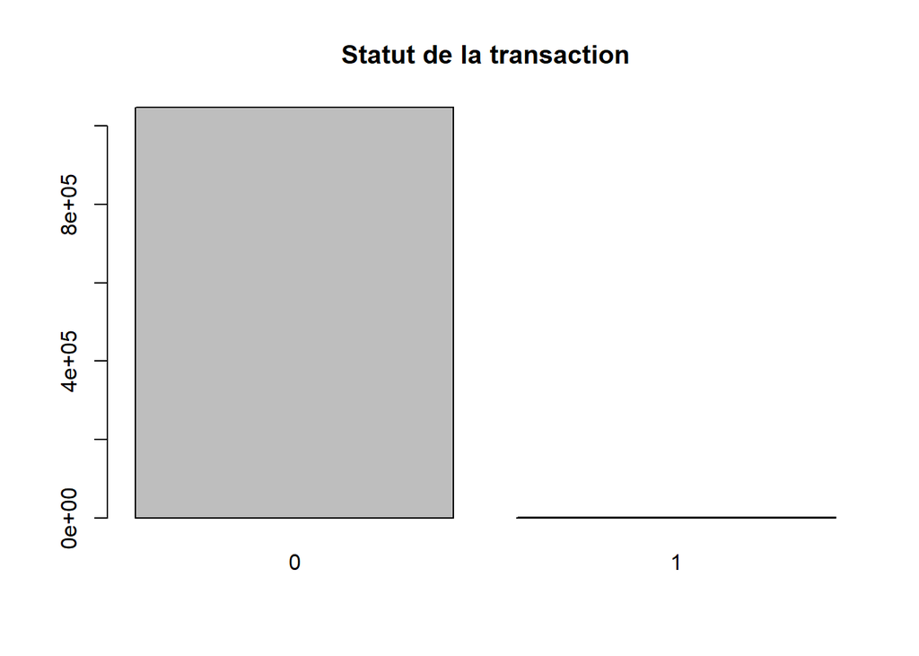

```r
plot(df$isFraud, main = "Statut de la transaction")
```

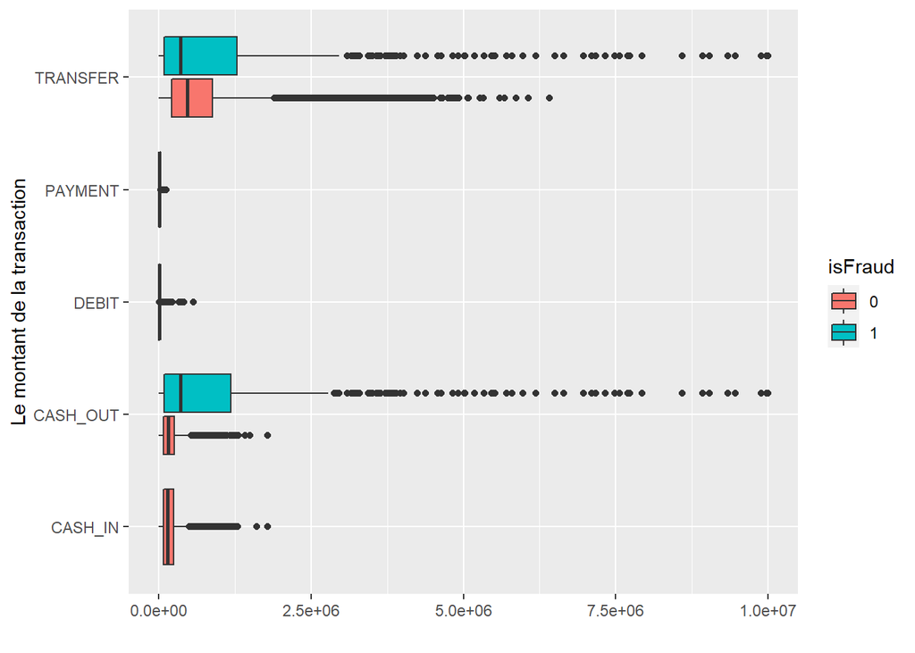

```r
ggplot(df, aes(x = amount, y=type, fill = isFraud)) +
    geom_boxplot() +
    labs(x = "", y = "Le montant de la transaction")
```

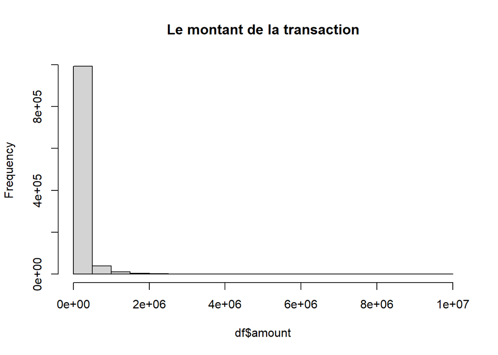

```r
hist(df$amount, main = "Le montant de la transaction")
```

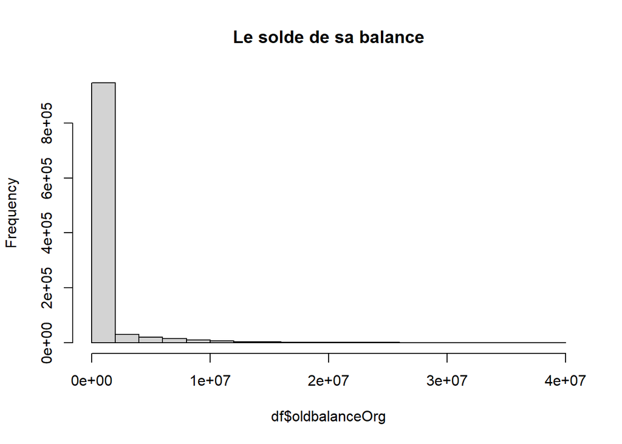

```r
hist(df$oldbalanceOrg, main = "Le solde de sa balance")
```

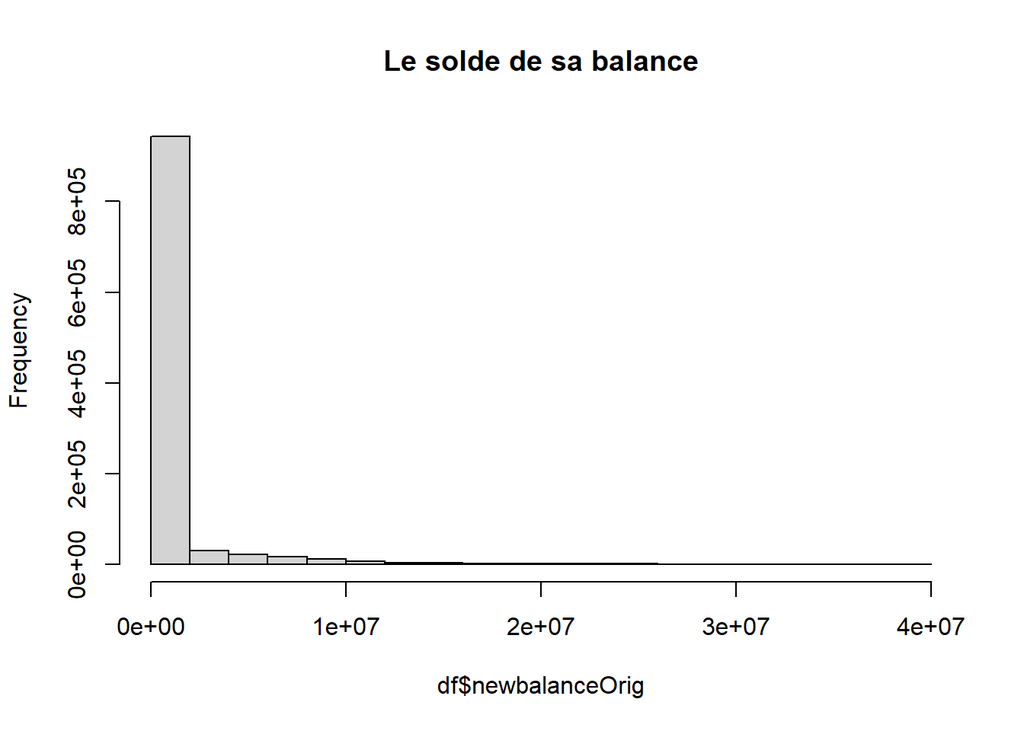

```r
hist(df$newbalanceOrig, main = "Le solde de sa balance")
```

[figure not shown]

[output not shown]

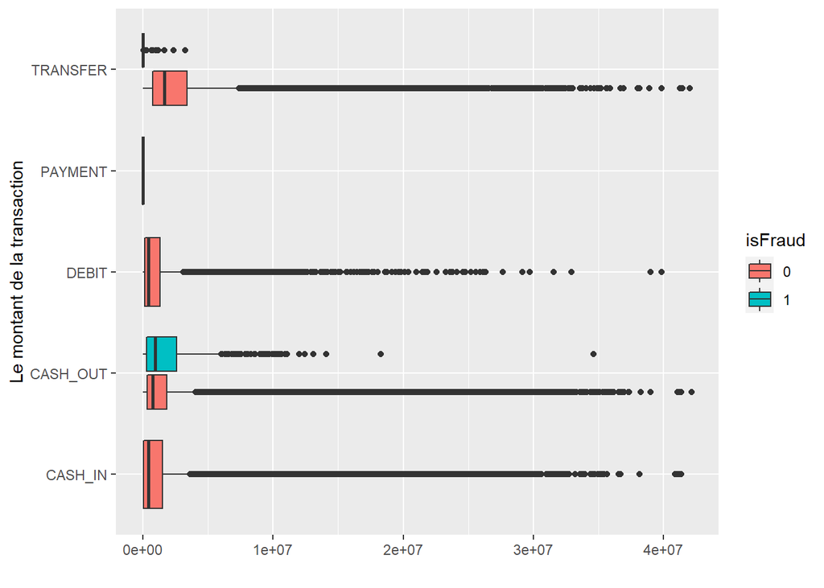

```r
ggplot(df, aes(x = oldbalanceDest, y=type, fill = isFraud)) +
    geom_boxplot() +
    labs(x = "", y = "Le montant de la transaction")
```